# Pandas-Bootcamp-Part4

### DataFrames

- The Structure and Content of dataframes
- new data : nutrition info
- hands-on data munging and prep
- plus: sampling , random numbers and more

```python
import pandas as pd
import numpy as np
```

```python
pd.__version__
```

```
'1.0.5'
```

```python
#We are looking at a collection of three different Python lists
#Strings , Integers and Booleans
```

```python
names = ['Olga' , 'Andrew' , 'Brian' , 'Telulah' , 'Nicole' , 'Tilda']
ages = [29 , 21 , 45 , 23 , 39 , 46]
married = [False , True , True , True , False , True]
```

```python
print(len(names))
print(len(ages))
print(len(married))
```

```
6
6
6
```

```python
#Pandas Series
ser = pd.Series(names , name = 'name')
```

```python
ser
```

```
0       Olga
1     Andrew
2      Brian
3    Telulah
4     Nicole
5      Tilda
Name: name, dtype: object
```

```python
#Pandas DataFrame
df = pd.DataFrame({'name' : names , 'age' : ages , 'married' : married})
```

```python
df.head(5)
```

|  | name | age | married |
| --- | --- | --- | --- |
| 0 | Olga | 29 | False |
| 1 | Andrew | 21 | True |
| 2 | Brian | 45 | True |
| 3 | Telulah | 23 | True |
| 4 | Nicole | 39 | False |

### What is a DataFrame ?

A Dataframe is a table of data that contains a collection of Rows and Columns.

Series are one-dimensional objects DataFrames are two-dimensional : "labeled Indices" and "Columns"

Now we will be working with Two-dimensional Datasets.

### What is a Dimension?

If you look at a Series , it extends in only one direction.

- Working with series we would need at the most one piece of information. Example : To select any value in the Series, we would need to specify either the Index Label or the index position

```python
ser
```

```
0       Olga
1     Andrew
2      Brian
3    Telulah
4     Nicole
5      Tilda
Name: name, dtype: object
```

```python
#Example : If we are interested in 'Brian' we would say "index position 2"
ser.iloc[2]
```

```
'Brian'
```

But if we try to access "Brian" from the below dataframe , we would have to specify the index position [2] as well as the column position [0]

```python
df
```

|  | name | age | married |
| --- | --- | --- | --- |
| 0 | Olga | 29 | False |
| 1 | Andrew | 21 | True |
| 2 | Brian | 45 | True |
| 3 | Telulah | 23 | True |
| 4 | Nicole | 39 | False |
| 5 | Tilda | 46 | True |

```python
df.iloc[2,0]
```

```
'Brian'
```

## .ndim

It gives us the number of dimensions

```python
ser.ndim
```

```
1
```

```python
df.ndim
```

```
2
```

### .shape

```python
ser.shape
```

```
(6,)
```

- We have 6 records in our Series

```python
df.shape
```

```
(6, 3)
```

- 6 rows and 3 columns
- A Series has only labeled Indices
- DataFrames have labeled Indices and Columns
- Each column in a DataFrame is a Series
- think of Dataframe as a Collection of Series

```python
ser
```

```
0       Olga
1     Andrew
2      Brian
3    Telulah
4     Nicole
5      Tilda
Name: name, dtype: object
```

```python
df.name
```

```
0       Olga
1     Andrew
2      Brian
3    Telulah
4     Nicole
5      Tilda
Name: name, dtype: object
```

#### Unlike Series , DataFrames can be Heterogenous

```python
ser.dtype
```

```
dtype('O')
```

Since a DataFRame has so many different datatypes in each column , we need to use dtypes and not dtype

```python
df.dtypes
```

```
name       object
age         int64
married      bool
dtype: object
```

https://www.udemy.com/course/the-ultimate-pandas-bootcamp-advanced-python-data-analysis/learn/lecture/18350472#overview

### Creating a DataFrame

```python
names
```

```
['Olga', 'Andrew', 'Brian', 'Telulah', 'Nicole', 'Tilda']
```

```python
ages
```

```
[29, 21, 45, 23, 39, 46]
```

```python
married
```

```
[False, True, True, True, False, True]
```

```python
#The list needs to be of equal length
```

```python
pd.DataFrame({'name' : names , 'age' : ages , 'married' : married})
```

|  | name | age | married |
| --- | --- | --- | --- |
| 0 | Olga | 29 | False |
| 1 | Andrew | 21 | True |
| 2 | Brian | 45 | True |
| 3 | Telulah | 23 | True |
| 4 | Nicole | 39 | False |
| 5 | Tilda | 46 | True |

### More ways of creating DataFrame

### Build a DataFrame from Tuples

```python
#we convert all three lists to tuples
#Remember both lists and tuples are ordered and iterable but
#Unlike lists Tuples are Immutable
tuple_names = tuple(names)
tuple_ages = tuple(ages)
tuple_married = tuple(married)
```

```python
#This is a Tuple
tuple_names
```

```
('Olga', 'Andrew', 'Brian', 'Telulah', 'Nicole', 'Tilda')
```

```python
#This is a List
names
```

```
['Olga', 'Andrew', 'Brian', 'Telulah', 'Nicole', 'Tilda']
```

```python
pd.DataFrame({'name' : tuple_names ,
             'ages' : tuple_ages,
             'married' : tuple_married})
```

|  | name | ages | married |
| --- | --- | --- | --- |
| 0 | Olga | 29 | False |
| 1 | Andrew | 21 | True |
| 2 | Brian | 45 | True |
| 3 | Telulah | 23 | True |
| 4 | Nicole | 39 | False |
| 5 | Tilda | 46 | True |

### Build a DataFrame from Series

```python
#dict of Series
#using lists as input to build individual Series
series_names = pd.Series(names)
series_ages = pd.Series(ages)
series_married = pd.Series(married)
```

```python
type(series_names)
```

```
pandas.core.series.Series
```

```python
pd.DataFrame({'name' : series_names ,
             'age' : series_ages,
             'married' : series_married})
```

|  | name | age | married |
| --- | --- | --- | --- |
| 0 | Olga | 29 | False |
| 1 | Andrew | 21 | True |
| 2 | Brian | 45 | True |
| 3 | Telulah | 23 | True |
| 4 | Nicole | 39 | False |
| 5 | Tilda | 46 | True |

### Build DataFrame from Dictionary of Dictionaries

```python
pd.DataFrame({'names' : {0 : 'Olga' , 1 : 'Andrew'}})
```

|  | names |
| --- | --- |
| 0 | Olga |
| 1 | Andrew |

```python
#We use a built-in Python function called "enumerate"
#which is like an Iterator with "counter" combined
#Using enumerate we will traverse all the three lists as well as access each item's Position at the same time
#The below code just gives us a place in memory
enumerate(names)
```

```
<enumerate at 0x208fadceac0>
```

```python
#We will wrap it in a list
list(enumerate(names))
```

```
[(0, 'Olga'),
 (1, 'Andrew'),
 (2, 'Brian'),
 (3, 'Telulah'),
 (4, 'Nicole'),
 (5, 'Tilda')]
```

- enumerator is an iterator that gets us pairs of tuples containing the value of each item as well as its position in the iterable (which is the list here) , which is exactly what we need to create dictionaries
- we want to get the output in this format
- {0 : 'Olga' , 1 : 'Andrew'}})

```python
names
```

```
['Olga', 'Andrew', 'Brian', 'Telulah', 'Nicole', 'Tilda']
```

```python
#We use Dictionary comprehension to create Key value pairs
dict_names = {k:v for k,v in enumerate(names)}
```

```python
dict_names
```

```
{0: 'Olga', 1: 'Andrew', 2: 'Brian', 3: 'Telulah', 4: 'Nicole', 5: 'Tilda'}
```

```python
dict_ages = {k:v for k,v in enumerate(ages)}
dict_married = {k:v for k,v in enumerate(married)}
```

#### We can also define a function for the above exercise

```python
def convert_list_to_dict(l):
    return{k:v for k,v in enumerate(l)}
```

```python
dict_names = convert_list_to_dict(names)
```

```python
dict_ages = convert_list_to_dict(ages)
```

```python
dict_married = convert_list_to_dict(married)
```

```python
dict_names
```

```
{0: 'Olga', 1: 'Andrew', 2: 'Brian', 3: 'Telulah', 4: 'Nicole', 5: 'Tilda'}
```

```python
dict_ages
```

```
{0: 29, 1: 21, 2: 45, 3: 23, 4: 39, 5: 46}
```

```python
dict_married
```

```
{0: False, 1: True, 2: True, 3: True, 4: False, 5: True}
```

#### WE construct a DataFrame using Dict of Dict approach

```python
pd.DataFrame({'name' : dict_names ,
             'ages' : dict_ages ,
             'married' : dict_married})
```

|  | name | ages | married |
| --- | --- | --- | --- |
| 0 | Olga | 29 | False |
| 1 | Andrew | 21 | True |
| 2 | Brian | 45 | True |
| 3 | Telulah | 23 | True |
| 4 | Nicole | 39 | False |
| 5 | Tilda | 46 | True |

All the above methods used a Column-wise approach to build the DataFrame

We can also use a Row-wise approach

### List of Dicts

```python
#This is how we create the first Row

pd.DataFrame([{
    'name' : 'Olga',
    'age' : 29,
    'married' : False
}])
```

|  | name | age | married |
| --- | --- | --- | --- |
| 0 | Olga | 29 | False |

#### We use the Zip method here . It combines values from more than one Iterable into a List of Tuples.

```python
names
```

```
['Olga', 'Andrew', 'Brian', 'Telulah', 'Nicole', 'Tilda']
```

```python
ages
```

```
[29, 21, 45, 23, 39, 46]
```

```python
married
```

```
[False, True, True, True, False, True]
```

```python
list(zip(names , ages , married))
```

```
[('Olga', 29, False),
 ('Andrew', 21, True),
 ('Brian', 45, True),
 ('Telulah', 23, True),
 ('Nicole', 39, False),
 ('Tilda', 46, True)]
```

```python
rowwise = [{'name' : name , 'age' : ages , 'married' : married} for name, ages, married in zip(names , ages , married)]
```

```python
rowwise
```

```
[{'name': 'Olga', 'age': 29, 'married': False},
 {'name': 'Andrew', 'age': 21, 'married': True},
 {'name': 'Brian', 'age': 45, 'married': True},
 {'name': 'Telulah', 'age': 23, 'married': True},
 {'name': 'Nicole', 'age': 39, 'married': False},
 {'name': 'Tilda', 'age': 46, 'married': True}]
```

```python
#we pass it to the DataFrame Constructor
pd.DataFrame(rowwise)
```

|  | name | age | married |
| --- | --- | --- | --- |
| 0 | Olga | 29 | False |
| 1 | Andrew | 21 | True |
| 2 | Brian | 45 | True |
| 3 | Telulah | 23 | True |
| 4 | Nicole | 39 | False |
| 5 | Tilda | 46 | True |

### The info() method

info() method gives a brief summary of what a DataFrame consists of

```python
df.info()
```

```
<class 'pandas.core.frame.DataFrame'>
RangeIndex: 6 entries, 0 to 5
Data columns (total 3 columns):
 #   Column   Non-Null Count  Dtype
---  ------   --------------  -----
 0   name     6 non-null      object
 1   age      6 non-null      int64
 2   married  6 non-null      bool
dtypes: bool(1), int64(1), object(1)
memory usage: 230.0+ bytes
```

- We have the information of index : RangeIndex: 6 entries, 0 to 5
- Also how much memory our DataFrame takes

```python
#No info about the Columns is printed
df.info(verbose = False)
```

```
<class 'pandas.core.frame.DataFrame'>
RangeIndex: 6 entries, 0 to 5
Columns: 3 entries, name to married
dtypes: bool(1), int64(1), object(1)
memory usage: 230.0+ bytes
```

```python
df
```

|  | name | age | married |
| --- | --- | --- | --- |
| 0 | Olga | 29 | False |
| 1 | Andrew | 21 | True |
| 2 | Brian | 45 | True |
| 3 | Telulah | 23 | True |
| 4 | Nicole | 39 | False |
| 5 | Tilda | 46 | True |

```python
df.info(max_cols = 3)
```

```
<class 'pandas.core.frame.DataFrame'>
RangeIndex: 6 entries, 0 to 5
Data columns (total 3 columns):
 #   Column   Non-Null Count  Dtype
---  ------   --------------  -----
 0   name     6 non-null      object
 1   age      6 non-null      int64
 2   married  6 non-null      bool
dtypes: bool(1), int64(1), object(1)
memory usage: 230.0+ bytes
```

```python
df.info(memory_usage = False)
```

```
<class 'pandas.core.frame.DataFrame'>
RangeIndex: 6 entries, 0 to 5
Data columns (total 3 columns):
 #   Column   Non-Null Count  Dtype
---  ------   --------------  -----
 0   name     6 non-null      object
 1   age      6 non-null      int64
 2   married  6 non-null      bool
dtypes: bool(1), int64(1), object(1)
```

### Reading in Nutrition Data

```python
dataurl = "https://andybek.com/pandas-nutrition"
```

```python
nutri = pd.read_csv('Nutrition.csv')
```

```python
nutri.head()
```

|  | Unnamed: 0 | name | serving_size | calories | total_fat | saturated_fat | cholesterol | sodium | choline | folate | ... | fat | saturated_fatty_acids | monounsaturated_fatty_acids | polyunsaturated_fatty_acids | fatty_acids_total_trans | alcohol | ash | caffeine | theobromine | water |
| --- | --- | --- | --- | --- | --- | --- | --- | --- | --- | --- | --- | --- | --- | --- | --- | --- | --- | --- | --- | --- | --- |
| 0 | 0 | Cornstarch | 100 g | 381 | 0.1g | NaN | 0 | 9.00 mg | 0.4 mg | 0.00 mcg | ... | 0.05 g | 0.009 g | 0.016 g | 0.025 g | 0.00 mg | 0.0 g | 0.09 g | 0.00 mg | 0.00 mg | 8.32 g |
| 1 | 1 | Nuts, pecans | 100 g | 691 | 72g | 6.2g | 0 | 0.00 mg | 40.5 mg | 22.00 mcg | ... | 71.97 g | 6.180 g | 40.801 g | 21.614 g | 0.00 mg | 0.0 g | 1.49 g | 0.00 mg | 0.00 mg | 3.52 g |
| 2 | 2 | Eggplant, raw | 100 g | 25 | 0.2g | NaN | 0 | 2.00 mg | 6.9 mg | 22.00 mcg | ... | 0.18 g | 0.034 g | 0.016 g | 0.076 g | 0.00 mg | 0.0 g | 0.66 g | 0.00 mg | 0.00 mg | 92.30 g |
| 3 | 3 | Teff, uncooked | 100 g | 367 | 2.4g | 0.4g | 0 | 12.00 mg | 13.1 mg | 0 | ... | 2.38 g | 0.449 g | 0.589 g | 1.071 g | 0 | 0 | 2.37 g | 0 | 0 | 8.82 g |
| 4 | 4 | Sherbet, orange | 100 g | 144 | 2g | 1.2g | 1mg | 46.00 mg | 7.7 mg | 4.00 mcg | ... | 2.00 g | 1.160 g | 0.530 g | 0.080 g | 1.00 mg | 0.0 g | 0.40 g | 0.00 mg | 0.00 mg | 66.10 g |

5 rows × 77 columns

```python
nutrition.info(verbose = False)
```

```
<class 'pandas.core.frame.DataFrame'>
RangeIndex: 8789 entries, 0 to 8788
Columns: 77 entries, Unnamed: 0 to water
dtypes: int64(3), object(74)
memory usage: 5.2+ MB
```

### Some Cleanup : Removing the Duplicated Index

https://www.udemy.com/course/the-ultimate-pandas-bootcamp-advanced-python-data-analysis/learn/lecture/18378366#overview

```python
nutri.head(2)
```

|  | Unnamed: 0 | name | serving_size | calories | total_fat | saturated_fat | cholesterol | sodium | choline | folate | ... | fat | saturated_fatty_acids | monounsaturated_fatty_acids | polyunsaturated_fatty_acids | fatty_acids_total_trans | alcohol | ash | caffeine | theobromine | water |
| --- | --- | --- | --- | --- | --- | --- | --- | --- | --- | --- | --- | --- | --- | --- | --- | --- | --- | --- | --- | --- | --- |
| 0 | 0 | Cornstarch | 100 g | 381 | 0.1g | NaN | 0 | 9.00 mg | 0.4 mg | 0.00 mcg | ... | 0.05 g | 0.009 g | 0.016 g | 0.025 g | 0.00 mg | 0.0 g | 0.09 g | 0.00 mg | 0.00 mg | 8.32 g |
| 1 | 1 | Nuts, pecans | 100 g | 691 | 72g | 6.2g | 0 | 0.00 mg | 40.5 mg | 22.00 mcg | ... | 71.97 g | 6.180 g | 40.801 g | 21.614 g | 0.00 mg | 0.0 g | 1.49 g | 0.00 mg | 0.00 mg | 3.52 g |

2 rows × 77 columns

```python
#We have Duplicated Index in the dataset
#You can see an extra column "Unnamed 0" that looks like a repitition of our range index

nutri.columns
```

```
Index(['Unnamed: 0', 'name', 'serving_size', 'calories', 'total_fat',
       'saturated_fat', 'cholesterol', 'sodium', 'choline', 'folate',
       'folic_acid', 'niacin', 'pantothenic_acid', 'riboflavin', 'thiamin',
       'vitamin_a', 'vitamin_a_rae', 'carotene_alpha', 'carotene_beta',
       'cryptoxanthin_beta', 'lutein_zeaxanthin', 'lucopene', 'vitamin_b12',
       'vitamin_b6', 'vitamin_c', 'vitamin_d', 'vitamin_e', 'tocopherol_alpha',
       'vitamin_k', 'calcium', 'copper', 'irom', 'magnesium', 'manganese',
       'phosphorous', 'potassium', 'selenium', 'zink', 'protein', 'alanine',
       'arginine', 'aspartic_acid', 'cystine', 'glutamic_acid', 'glycine',
       'histidine', 'hydroxyproline', 'isoleucine', 'leucine', 'lysine',
       'methionine', 'phenylalanine', 'proline', 'serine', 'threonine',
       'tryptophan', 'tyrosine', 'valine', 'carbohydrate', 'fiber', 'sugars',
       'fructose', 'galactose', 'glucose', 'lactose', 'maltose', 'sucrose',
       'fat', 'saturated_fatty_acids', 'monounsaturated_fatty_acids',
       'polyunsaturated_fatty_acids', 'fatty_acids_total_trans', 'alcohol',
       'ash', 'caffeine', 'theobromine', 'water'],
      dtype='object')
```

```python
nutri['Unnamed: 0']
```

```
0          0
1          1
2          2
3          3
4          4
        ...
8784    8784
8785    8785
8786    8786
8787    8787
8788    8788
Name: Unnamed: 0, Length: 8789, dtype: int64
```

```python
#Remove this column
#axis 1 means columns , axis 0 means Rows
nutri.drop('Unnamed: 0' , axis = 1)
```

|  | name | serving_size | calories | total_fat | saturated_fat | cholesterol | sodium | choline | folate | folic_acid | ... | fat | saturated_fatty_acids | monounsaturated_fatty_acids | polyunsaturated_fatty_acids | fatty_acids_total_trans | alcohol | ash | caffeine | theobromine | water |
| --- | --- | --- | --- | --- | --- | --- | --- | --- | --- | --- | --- | --- | --- | --- | --- | --- | --- | --- | --- | --- | --- |
| 0 | Cornstarch | 100 g | 381 | 0.1g | NaN | 0 | 9.00 mg | 0.4 mg | 0.00 mcg | 0.00 mcg | ... | 0.05 g | 0.009 g | 0.016 g | 0.025 g | 0.00 mg | 0.0 g | 0.09 g | 0.00 mg | 0.00 mg | 8.32 g |
| 1 | Nuts, pecans | 100 g | 691 | 72g | 6.2g | 0 | 0.00 mg | 40.5 mg | 22.00 mcg | 0.00 mcg | ... | 71.97 g | 6.180 g | 40.801 g | 21.614 g | 0.00 mg | 0.0 g | 1.49 g | 0.00 mg | 0.00 mg | 3.52 g |
| 2 | Eggplant, raw | 100 g | 25 | 0.2g | NaN | 0 | 2.00 mg | 6.9 mg | 22.00 mcg | 0.00 mcg | ... | 0.18 g | 0.034 g | 0.016 g | 0.076 g | 0.00 mg | 0.0 g | 0.66 g | 0.00 mg | 0.00 mg | 92.30 g |
| 3 | Teff, uncooked | 100 g | 367 | 2.4g | 0.4g | 0 | 12.00 mg | 13.1 mg | 0 | 0 | ... | 2.38 g | 0.449 g | 0.589 g | 1.071 g | 0 | 0 | 2.37 g | 0 | 0 | 8.82 g |
| 4 | Sherbet, orange | 100 g | 144 | 2g | 1.2g | 1mg | 46.00 mg | 7.7 mg | 4.00 mcg | 0.00 mcg | ... | 2.00 g | 1.160 g | 0.530 g | 0.080 g | 1.00 mg | 0.0 g | 0.40 g | 0.00 mg | 0.00 mg | 66.10 g |
| ... | ... | ... | ... | ... | ... | ... | ... | ... | ... | ... | ... | ... | ... | ... | ... | ... | ... | ... | ... | ... | ... |
| 8784 | Beef, raw, all grades, trimmed to 0" fat, sepa... | 100 g | 125 | 3.5g | 1.4g | 62mg | 54.00 mg | 64.5 mg | 4.00 mcg | 0.00 mcg | ... | 3.50 g | 1.353 g | 1.554 g | 0.244 g | 62.00 mg | 0.0 g | 1.11 g | 0.00 mg | 0.00 mg | 72.51 g |
| 8785 | Lamb, cooked, separable lean only, composite o... | 100 g | 206 | 8.9g | 3.9g | 109mg | 50.00 mg | 0 | 0.00 mcg | 0.00 mcg | ... | 8.86 g | 3.860 g | 3.480 g | 0.520 g | 109.00 mg | 0 | 1.60 g | 0 | 0 | 59.95 g |
| 8786 | Lamb, raw, separable lean and fat, composite o... | 100 g | 277 | 23g | 12g | 78mg | 39.00 mg | 0 | 1.00 mcg | 0.00 mcg | ... | 22.74 g | 11.570 g | 8.720 g | 0.980 g | 78.00 mg | 0 | 0.92 g | 0 | 0 | 59.80 g |
| 8787 | Beef, raw, all grades, trimmed to 0" fat, sepa... | 100 g | 121 | 3g | 1.1g | 60mg | 53.00 mg | 64.2 mg | 4.00 mcg | 0.00 mcg | ... | 3.04 g | 1.086 g | 1.266 g | 0.233 g | 60.00 mg | 0.0 g | 1.10 g | 0.00 mg | 0.00 mg | 73.43 g |
| 8788 | Beef, raw, all grades, trimmed to 0" fat, sepa... | 100 g | 121 | 3g | 1.1g | 60mg | 53.00 mg | 64.2 mg | 4.00 mcg | 0.00 mcg | ... | 3.04 g | 1.086 g | 1.266 g | 0.233 g | 60.00 mg | 0.0 g | 1.10 g | 0.00 mg | 0.00 mg | 73.43 g |

8789 rows × 76 columns

```python
#Or instead of dropping the 'Unnamed: 0' column , we can simply make it the Index
nutri.set_index('Unnamed: 0')
```

| Unnamed: 0 | name | serving_size | calories | total_fat | saturated_fat | cholesterol | sodium | choline | folate | folic_acid | ... | fat | saturated_fatty_acids | monounsaturated_fatty_acids | polyunsaturated_fatty_acids | fatty_acids_total_trans | alcohol | ash | caffeine | theobromine | water |
| --- | --- | --- | --- | --- | --- | --- | --- | --- | --- | --- | --- | --- | --- | --- | --- | --- | --- | --- | --- | --- | --- |
| 0 | Cornstarch | 100 g | 381 | 0.1g | NaN | 0 | 9.00 mg | 0.4 mg | 0.00 mcg | 0.00 mcg | ... | 0.05 g | 0.009 g | 0.016 g | 0.025 g | 0.00 mg | 0.0 g | 0.09 g | 0.00 mg | 0.00 mg | 8.32 g |
| 1 | Nuts, pecans | 100 g | 691 | 72g | 6.2g | 0 | 0.00 mg | 40.5 mg | 22.00 mcg | 0.00 mcg | ... | 71.97 g | 6.180 g | 40.801 g | 21.614 g | 0.00 mg | 0.0 g | 1.49 g | 0.00 mg | 0.00 mg | 3.52 g |
| 2 | Eggplant, raw | 100 g | 25 | 0.2g | NaN | 0 | 2.00 mg | 6.9 mg | 22.00 mcg | 0.00 mcg | ... | 0.18 g | 0.034 g | 0.016 g | 0.076 g | 0.00 mg | 0.0 g | 0.66 g | 0.00 mg | 0.00 mg | 92.30 g |
| 3 | Teff, uncooked | 100 g | 367 | 2.4g | 0.4g | 0 | 12.00 mg | 13.1 mg | 0 | 0 | ... | 2.38 g | 0.449 g | 0.589 g | 1.071 g | 0 | 0 | 2.37 g | 0 | 0 | 8.82 g |
| 4 | Sherbet, orange | 100 g | 144 | 2g | 1.2g | 1mg | 46.00 mg | 7.7 mg | 4.00 mcg | 0.00 mcg | ... | 2.00 g | 1.160 g | 0.530 g | 0.080 g | 1.00 mg | 0.0 g | 0.40 g | 0.00 mg | 0.00 mg | 66.10 g |
| ... | ... | ... | ... | ... | ... | ... | ... | ... | ... | ... | ... | ... | ... | ... | ... | ... | ... | ... | ... | ... | ... |
| 8784 | Beef, raw, all grades, trimmed to 0" fat, sepa... | 100 g | 125 | 3.5g | 1.4g | 62mg | 54.00 mg | 64.5 mg | 4.00 mcg | 0.00 mcg | ... | 3.50 g | 1.353 g | 1.554 g | 0.244 g | 62.00 mg | 0.0 g | 1.11 g | 0.00 mg | 0.00 mg | 72.51 g |
| 8785 | Lamb, cooked, separable lean only, composite o... | 100 g | 206 | 8.9g | 3.9g | 109mg | 50.00 mg | 0 | 0.00 mcg | 0.00 mcg | ... | 8.86 g | 3.860 g | 3.480 g | 0.520 g | 109.00 mg | 0 | 1.60 g | 0 | 0 | 59.95 g |
| 8786 | Lamb, raw, separable lean and fat, composite o... | 100 g | 277 | 23g | 12g | 78mg | 39.00 mg | 0 | 1.00 mcg | 0.00 mcg | ... | 22.74 g | 11.570 g | 8.720 g | 0.980 g | 78.00 mg | 0 | 0.92 g | 0 | 0 | 59.80 g |
| 8787 | Beef, raw, all grades, trimmed to 0" fat, sepa... | 100 g | 121 | 3g | 1.1g | 60mg | 53.00 mg | 64.2 mg | 4.00 mcg | 0.00 mcg | ... | 3.04 g | 1.086 g | 1.266 g | 0.233 g | 60.00 mg | 0.0 g | 1.10 g | 0.00 mg | 0.00 mg | 73.43 g |
| 8788 | Beef, raw, all grades, trimmed to 0" fat, sepa... | 100 g | 121 | 3g | 1.1g | 60mg | 53.00 mg | 64.2 mg | 4.00 mcg | 0.00 mcg | ... | 3.04 g | 1.086 g | 1.266 g | 0.233 g | 60.00 mg | 0.0 g | 1.10 g | 0.00 mg | 0.00 mg | 73.43 g |

8789 rows × 76 columns

```python
#The other way to deal with this is , let pandas know , while reading the Dataframe itself that we want to
#set the "Unnamed 0" column as Index
#Below we pass the parameter "Index_col = 0" to make the first column as the Index

nutri = pd.read_csv('Nutrition.csv' , index_col = [0])
```

```python
nutri.head(2)
```

|  | name | serving_size | calories | total_fat | saturated_fat | cholesterol | sodium | choline | folate | folic_acid | ... | fat | saturated_fatty_acids | monounsaturated_fatty_acids | polyunsaturated_fatty_acids | fatty_acids_total_trans | alcohol | ash | caffeine | theobromine | water |
| --- | --- | --- | --- | --- | --- | --- | --- | --- | --- | --- | --- | --- | --- | --- | --- | --- | --- | --- | --- | --- | --- |
| 0 | Cornstarch | 100 g | 381 | 0.1g | NaN | 0 | 9.00 mg | 0.4 mg | 0.00 mcg | 0.00 mcg | ... | 0.05 g | 0.009 g | 0.016 g | 0.025 g | 0.00 mg | 0.0 g | 0.09 g | 0.00 mg | 0.00 mg | 8.32 g |
| 1 | Nuts, pecans | 100 g | 691 | 72g | 6.2g | 0 | 0.00 mg | 40.5 mg | 22.00 mcg | 0.00 mcg | ... | 71.97 g | 6.180 g | 40.801 g | 21.614 g | 0.00 mg | 0.0 g | 1.49 g | 0.00 mg | 0.00 mg | 3.52 g |

2 rows × 76 columns

### The sample() method

We can conveniently take random samples from our Dataset.

- When we call it on a DataFrame , it returns back a random observation

```python
nutri.sample()
```

|  | name | serving_size | calories | total_fat | saturated_fat | cholesterol | sodium | choline | folate | folic_acid | ... | fat | saturated_fatty_acids | monounsaturated_fatty_acids | polyunsaturated_fatty_acids | fatty_acids_total_trans | alcohol | ash | caffeine | theobromine | water |
| --- | --- | --- | --- | --- | --- | --- | --- | --- | --- | --- | --- | --- | --- | --- | --- | --- | --- | --- | --- | --- | --- |
| 8361 | Lamb, braised, cooked, trimmed to 1/8" fat, se... | 100 g | 311 | 20g | 9.7g | 106mg | 73.00 mg | 0 | 0 | 0 | ... | 20.38 g | 9.696 g | 8.173 g | 0.830 g | 106.00 mg | 0 | 0.93 g | 0 | 0 | 51.03 g |

1 rows × 76 columns

```python
#For others to get the same random sample , we can set the random_state parameter
nutri.sample(random_state = 12)
```

|  | name | serving_size | calories | total_fat | saturated_fat | cholesterol | sodium | choline | folate | folic_acid | ... | fat | saturated_fatty_acids | monounsaturated_fatty_acids | polyunsaturated_fatty_acids | fatty_acids_total_trans | alcohol | ash | caffeine | theobromine | water |
| --- | --- | --- | --- | --- | --- | --- | --- | --- | --- | --- | --- | --- | --- | --- | --- | --- | --- | --- | --- | --- | --- |
| 3713 | Thuringer, pork, beef, summer sausage, cervelat | 100 g | 362 | 30g | 12g | 74mg | 1300.00 mg | 78.9 mg | 2.00 mcg | 0.00 mcg | ... | 30.43 g | 11.510 g | 12.970 g | 1.200 g | 74.00 mg | 0.0 g | 3.63 g | 0.00 mg | 0.00 mg | 45.18 g |

1 rows × 76 columns

```python
#n simply specifies the number of records we want to get back
nutri.sample(n = 4)
```

|  | name | serving_size | calories | total_fat | saturated_fat | cholesterol | sodium | choline | folate | folic_acid | ... | fat | saturated_fatty_acids | monounsaturated_fatty_acids | polyunsaturated_fatty_acids | fatty_acids_total_trans | alcohol | ash | caffeine | theobromine | water |
| --- | --- | --- | --- | --- | --- | --- | --- | --- | --- | --- | --- | --- | --- | --- | --- | --- | --- | --- | --- | --- | --- |
| 915 | Milk, fluid, indian buffalo | 100 g | 97 | 6.9g | 4.6g | 19mg | 52.00 mg | 0 | 6.00 mcg | 0.00 mcg | ... | 6.89 g | 4.597 g | 1.787 g | 0.146 g | 19.00 mg | 0 | 0.79 g | 0 | 0 | 83.39 g |
| 4137 | Cookies, with extra creme filling, chocolate s... | 100 g | 497 | 25g | 5.5g | 0 | 351.00 mg | 3.3 mg | 46.00 mcg | 34.00 mcg | ... | 24.52 g | 5.454 g | 16.076 g | 2.471 g | 0.00 mg | 0.0 g | 1.30 g | 6.00 mg | 190.00 mg | 1.65 g |
| 6715 | Rice and vermicelli mix, prepared with 80% mar... | 100 g | 129 | 3.2g | 0.7g | 0 | 364.00 mg | 0 | 0 | 0 | ... | 3.20 g | 0.682 g | 1.126 g | 0.915 g | 0 | 0 | 1.01 g | 0 | 0 | 70.93 g |
| 5603 | Pork, raw, separable lean and fat, arm picnic,... | 100 g | 193 | 13g | 4.1g | 63mg | 84.00 mg | 64.2 mg | 0.00 mcg | 0.00 mcg | ... | 12.51 g | 4.140 g | 5.367 g | 2.474 g | 63.00 mg | 0.0 g | 0.98 g | 0.00 mg | 0.00 mg | 68.34 g |

4 rows × 76 columns

```python
#As an alternative to n , we can also pass a portion or a percent to the frac parameter
#If we want to sample 1% of our Dataframe

nutri.sample(frac = 0.01)
```

|  | name | serving_size | calories | total_fat | saturated_fat | cholesterol | sodium | choline | folate | folic_acid | ... | fat | saturated_fatty_acids | monounsaturated_fatty_acids | polyunsaturated_fatty_acids | fatty_acids_total_trans | alcohol | ash | caffeine | theobromine | water |
| --- | --- | --- | --- | --- | --- | --- | --- | --- | --- | --- | --- | --- | --- | --- | --- | --- | --- | --- | --- | --- | --- |
| 4726 | Chicken, raw, meat only, neck, broilers or fryers | 100 g | 154 | 8.8g | 2.3g | 83mg | 81.00 mg | 0 | 8.00 mcg | 0.00 mcg | ... | 8.78 g | 2.250 g | 2.730 g | 2.180 g | 83.00 mg | 0 | 0.69 g | 0 | 0 | 71.17 g |
| 5822 | Babyfood, toddler, chicken and noodle with veg... | 100 g | 66 | 1.7g | 0.5g | 28mg | 235.00 mg | 11.2 mg | 9.00 mcg | 4.00 mcg | ... | 1.70 g | 0.461 g | 0.632 g | 0.392 g | 28.00 mg | 0.0 g | 0.31 g | 0.00 mg | 0.00 mg | 85.30 g |
| 1198 | Guanabana nectar, canned | 100 g | 59 | 0.2g | NaN | 0 | 8.00 mg | 2.2 mg | 6.00 mcg | 0.00 mcg | ... | 0.17 g | 0.029 g | 0.051 g | 0.039 g | 0.00 mg | 0.0 g | 0.08 g | 0.00 mg | 0.00 mg | 84.72 g |
| 888 | Beverages, well, tap, water | 100 g | 0 | 0g | NaN | 0 | 0 | 0 | 0 | 0 | ... | 0.00 g | 0 | 0 | 0 | 0 | 0 | 0.10 g | 0 | 0 | 99.90 g |
| 8147 | Beef, raw, all grades, trimmed to 1/8" fat, se... | 100 g | 189 | 12g | 4.6g | 65mg | 58.00 mg | 81.9 mg | 7.00 mcg | 0.00 mcg | ... | 11.67 g | 4.600 g | 5.000 g | 0.460 g | 65.00 mg | 0.0 g | 0.95 g | 0.00 mg | 0.00 mg | 66.10 g |
| ... | ... | ... | ... | ... | ... | ... | ... | ... | ... | ... | ... | ... | ... | ... | ... | ... | ... | ... | ... | ... | ... |
| 7331 | Fast foods, large patty; with condiments and v... | 100 g | 235 | 13g | 4.8g | 40mg | 378.00 mg | 0 | 38.00 mcg | 21.00 mcg | ... | 12.55 g | 4.780 g | 5.240 g | 1.010 g | 40.00 mg | 0 | 1.56 g | 0 | 0 | 55.70 g |
| 5559 | Pork, raw, separable lean only, country-style ... | 100 g | 140 | 5.6g | 2g | 74mg | 67.00 mg | 87.3 mg | 0.00 mcg | 0.00 mcg | ... | 5.64 g | 2.012 g | 2.477 g | 0.645 g | 74.00 mg | 0.0 g | 1.01 g | 0.00 mg | 0.00 mg | 72.84 g |
| 3095 | Snacks, plain, chips, extruded, corn-based | 100 g | 538 | 33g | 4.3g | 0 | 514.00 mg | 12.1 mg | 8.00 mcg | 0.00 mcg | ... | 33.36 g | 4.331 g | 9.134 g | 16.438 g | 0.00 mg | 0.0 g | 2.13 g | 0.00 mg | 0.00 mg | 1.07 g |
| 441 | POPEYES, biscuit | 100 g | 401 | 24g | 12g | 2mg | 745.00 mg | 0 | 91.00 mcg | 0 | ... | 23.71 g | 11.515 g | 5.686 g | 4.379 g | 2.00 mg | 0 | 2.81 g | 0 | 0 | 26.52 g |
| 924 | Quail, total edible, cooked | 100 g | 227 | 14g | 4g | 86mg | 52.00 mg | 65.9 mg | 6.00 mcg | 0.00 mcg | ... | 14.10 g | 3.955 g | 4.891 g | 3.487 g | 86.00 mg | 0.0 g | 0.80 g | 0.00 mg | 0.00 mg | 60.00 g |

88 rows × 76 columns

- Our data consists of almost 9000 records , 1% of that gave us almost 90 Records

```python
nutri.shape
```

```
(8789, 76)
```

```python
#How much is 1% of 8789
nutri.shape[0] * 0.01
```

```
87.89
```

```python
#50% of 8789 is :
nutri.shape[0] * 0.50
```

```
4394.5
```

### Sampling with Replacement or Weights

Think of sampling as choosing something from a hat and the hat contains all the possible values in our population. When we sample with replacement , we choose to put this record that we just selected back into the hat. The idea is to exact same record multiple times. This is also known as "BootStrapping" in Statistics

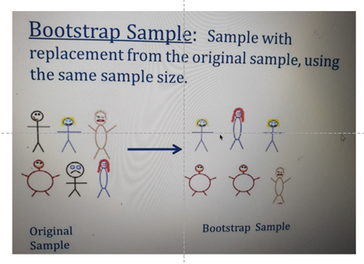

Above you can see we end up choosing the same element more than once.

### Sampling with or without Replacement

```python
#Since we are working with a large dataset , picking the same record is quite unlikely though
```

```python
nutrition.sample(n=3 , replace = True)
```

|  | Unnamed: 0 | name | serving_size | calories | total_fat | saturated_fat | cholesterol | sodium | choline | folate | ... | fat | saturated_fatty_acids | monounsaturated_fatty_acids | polyunsaturated_fatty_acids | fatty_acids_total_trans | alcohol | ash | caffeine | theobromine | water |
| --- | --- | --- | --- | --- | --- | --- | --- | --- | --- | --- | --- | --- | --- | --- | --- | --- | --- | --- | --- | --- | --- |
| 2769 | 2769 | Candies, chocolate-flavor roll, TOOTSIE ROLL | 100 g | 387 | 3.3g | 1g | 2mg | 44.00 mg | 0 | 9.00 mcg | ... | 3.31 g | 0.967 g | 1.929 g | 0.266 g | 2.00 mg | 0 | 0.68 g | 7.00 mg | 75.00 mg | 6.69 g |
| 2242 | 2242 | Babyfood, strained, mixed fruit yogurt | 100 g | 75 | 0.8g | 0.5g | 0 | 16.00 mg | 4.5 mg | 2.00 mcg | ... | 0.80 g | 0.517 g | 0.219 g | 0.022 g | 0.00 mg | 0.0 g | 0.37 g | 0.00 mg | 0.00 mg | 81.80 g |
| 3186 | 3186 | WORTHINGTON Stakelets, unprepared, frozen | 100 g | 211 | 10g | 1.8g | 1mg | 651.00 mg | 0 | 0 | ... | 10.40 g | 1.800 g | 3.500 g | 5.100 g | 1.00 mg | 0 | 2.90 g | 0 | 0 | 57.50 g |

3 rows × 77 columns

### Weighted Sampling

The Probability of choosing any one sample or element from the set is Equal.

Here we label our samples with specific weights and then we take those weights into consideration when we do the ' sampling.

```python
#We create a Pandas series and assign it to the "weights" variable.
#To the "data" parameter , we specify the weights
#We call these relative weights because Pandas will normalize it behind the scenes anyway
#In other words these weights don't necessarily have to add up 1 or 100%
#To the index parameter , we pass the values that im interested in sampling by referencing their Index Labels
```

```python
weights = pd.Series(data = [10, 10, 10, 1, 2] , index = [7 , 17 , 29 , 5 , 6])
```

```python
#So, weights is just a pandas seies now
weights
```

```
7     10
17    10
29    10
5      1
6      2
dtype: int64
```

#### 7 , 17 and 29 are heavily weighted Indices which are very likely to be picked

```python
nutri.sample(n = 5 , weights = weights)
```

|  | name | serving_size | calories | total_fat | saturated_fat | cholesterol | sodium | choline | folate | folic_acid | ... | fat | saturated_fatty_acids | monounsaturated_fatty_acids | polyunsaturated_fatty_acids | fatty_acids_total_trans | alcohol | ash | caffeine | theobromine | water |
| --- | --- | --- | --- | --- | --- | --- | --- | --- | --- | --- | --- | --- | --- | --- | --- | --- | --- | --- | --- | --- | --- |
| 29 | Nuts, dried, pine nuts | 100 g | 673 | 68g | 4.9g | 0 | 2.00 mg | 55.8 mg | 34.00 mcg | 0.00 mcg | ... | 68.37 g | 4.899 g | 18.764 g | 34.071 g | 0.00 mg | 0.0 g | 2.59 g | 0.00 mg | 0.00 mg | 2.28 g |
| 17 | Peppers, raw, jalapeno | 100 g | 29 | 0.4g | 0.1g | 0 | 3.00 mg | 7.5 mg | 27.00 mcg | 0.00 mcg | ... | 0.37 g | 0.092 g | 0.029 g | 0.112 g | 0.00 mg | 0.0 g | 0.53 g | 0.00 mg | 0.00 mg | 91.69 g |
| 7 | Lamb, raw, ground | 100 g | 282 | 23g | 10g | 73mg | 59.00 mg | 69.3 mg | 18.00 mcg | 0.00 mcg | ... | 23.41 g | 10.190 g | 9.600 g | 1.850 g | 73.00 mg | 0.0 g | 0.87 g | 0.00 mg | 0.00 mg | 59.47 g |
| 6 | Taro leaves, raw | 100 g | 42 | 0.7g | 0.2g | 0 | 3.00 mg | 12.8 mg | 126.00 mcg | 0.00 mcg | ... | 0.74 g | 0.151 g | 0.060 g | 0.307 g | 0.00 mg | 0.0 g | 1.92 g | 0.00 mg | 0.00 mg | 85.66 g |
| 5 | Cauliflower, raw | 100 g | 25 | 0.3g | 0.1g | 0 | 30.00 mg | 44.3 mg | 57.00 mcg | 0.00 mcg | ... | 0.28 g | 0.130 g | 0.034 g | 0.031 g | 0.00 mg | 0.0 g | 0.76 g | 0.00 mg | 0.00 mg | 92.07 g |

5 rows × 76 columns

```python
nutri.sample(n =20  )
```

|  | name | serving_size | calories | total_fat | saturated_fat | cholesterol | sodium | choline | folate | folic_acid | ... | fat | saturated_fatty_acids | monounsaturated_fatty_acids | polyunsaturated_fatty_acids | fatty_acids_total_trans | alcohol | ash | caffeine | theobromine | water |
| --- | --- | --- | --- | --- | --- | --- | --- | --- | --- | --- | --- | --- | --- | --- | --- | --- | --- | --- | --- | --- | --- |
| 7609 | Beef, raw, choice, trimmed to 0" fat, separabl... | 100 g | 131 | 5.2g | 2.1g | 67mg | 82.00 mg | 75.0 mg | 3.00 mcg | 0.00 mcg | ... | 5.18 g | 2.114 g | 2.576 g | 0.365 g | 67.00 mg | 0.0 g | 1.24 g | 0.00 mg | 0.00 mg | 72.83 g |
| 67 | Oil, soybean lecithin | 100 g | 763 | 100g | 15g | 0 | 0.00 mg | 350.0 mg | 0.00 mcg | 0.00 mcg | ... | 100.00 g | 15.005 g | 10.977 g | 45.318 g | 0.00 mg | 0.0 g | 0.00 g | 0.00 mg | 0.00 mg | 0.00 g |
| 5625 | CAMPBELL'S CHUNKY Soups, Slow Roasted Beef wit... | 100 g | 48 | 0.6g | 0.4g | 6mg | 339.00 mg | 0 | 0 | 0 | ... | 0.61 g | 0.408 g | 0 | 0 | 6.00 mg | 0 | 1.68 g | 0 | 0 | 87.10 g |
| 2967 | Cookies, baked, refrigerated dough, oatmeal | 100 g | 471 | 21g | 5.3g | 26mg | 327.00 mg | 0 | 27.00 mcg | 20.00 mcg | ... | 21.00 g | 5.339 g | 11.729 g | 2.976 g | 26.00 mg | 0 | 1.40 g | 0 | 0 | 5.80 g |
| 6989 | Lamb, braised, cooked, separable lean and fat,... | 100 g | 256 | 15g | 5.6g | 110mg | 74.00 mg | 0 | 0 | 0.00 mcg | ... | 14.99 g | 5.560 g | 4.119 g | 0.697 g | 110.00 mg | 0.0 g | 0.89 g | 0.00 mg | 0.00 mg | 55.58 g |
| 3330 | Alcoholic beverage, sweet, dessert, wine | 100 g | 160 | 0g | NaN | 0 | 9.00 mg | 5.0 mg | 0.00 mcg | 0.00 mcg | ... | 0.00 g | 0.000 g | 0.000 g | 0.000 g | 0.00 mg | 15.3 g | 0.30 g | 0.00 mg | 0.00 mg | 70.51 g |
| 939 | Bread, canned, boston brown | 100 g | 195 | 1.5g | 0.3g | 1mg | 631.00 mg | 23.5 mg | 11.00 mcg | 4.00 mcg | ... | 1.50 g | 0.282 g | 0.207 g | 0.564 g | 1.00 mg | 0.0 g | 2.80 g | 0.00 mg | 0.00 mg | 47.20 g |
| 5490 | Chicken, stewed, cooked, meat and skin, leg, b... | 100 g | 220 | 13g | 3.6g | 84mg | 73.00 mg | 56.4 mg | 6.00 mcg | 0.00 mcg | ... | 12.92 g | 3.570 g | 5.040 g | 2.870 g | 84.00 mg | 0.0 g | 0.79 g | 0.00 mg | 0.00 mg | 64.01 g |
| 352 | PACE, Salsa Verde | 100 g | 47 | 1.6g | NaN | 0 | 719.00 mg | 0 | 0 | 0 | ... | 1.56 g | 0.000 g | 0 | 0 | 0.00 mg | 0 | 4.09 g | 0 | 0 | 88.10 g |
| 7481 | Split pea with ham soup, prepared with water o... | 100 g | 68 | 0.7g | 0.3g | 3mg | 196.00 mg | 22.3 mg | 29.00 mcg | 0.00 mcg | ... | 0.70 g | 0.294 g | 0.282 g | 0.135 g | 3.00 mg | 0.0 g | 1.00 g | 0.00 mg | 0.00 mg | 82.80 g |
| 285 | Acerola juice, raw | 100 g | 23 | 0.3g | 0.1g | 0 | 3.00 mg | 0 | 14.00 mcg | 0.00 mcg | ... | 0.30 g | 0.068 g | 0.082 g | 0.090 g | 0.00 mg | 0.0 g | 0.20 g | 0.00 mg | 0.00 mg | 94.30 g |
| 8637 | Beef, raw, all grades, trimmed to 1/8" fat, se... | 100 g | 134 | 5.4g | 1.9g | 67mg | 55.00 mg | 0 | 3.00 mcg | 0.00 mcg | ... | 5.36 g | 1.875 g | 2.354 g | 0.189 g | 67.00 mg | 0.0 g | 0.98 g | 0.00 mg | 0.00 mg | 72.93 g |
| 3952 | Cake, dry mix, german chocolate, pudding-type | 100 g | 350 | 3.2g | 1.9g | 0 | 841.00 mg | 4.2 mg | 66.00 mcg | 20.00 mcg | ... | 3.24 g | 1.852 g | 0.694 g | 0.231 g | 0.00 mg | 0.0 g | 4.40 g | 7.00 mg | 242.00 mg | 6.94 g |
| 5866 | Restaurant, spaghetti with pomodoro sauce (no ... | 100 g | 104 | 1.9g | 0.4g | 0 | 191.00 mg | 8.0 mg | 29.00 mcg | 0 | ... | 1.89 g | 0.366 g | 0.926 g | 0.528 g | 0.00 mg | 0 | 0.89 g | 0 | 0 | 75.56 g |
| 5128 | Brussels sprouts, without salt, drained, boile... | 100 g | 36 | 0.5g | 0.1g | 0 | 21.00 mg | 40.6 mg | 60.00 mcg | 0.00 mcg | ... | 0.50 g | 0.102 g | 0.038 g | 0.255 g | 0.00 mg | 0.0 g | 0.95 g | 0.00 mg | 0.00 mg | 88.90 g |
| 7542 | Beef, braised, cooked, select, trimmed to 0" f... | 100 g | 206 | 6.3g | 2.2g | 91mg | 46.00 mg | 133.0 mg | 12.00 mcg | 0.00 mcg | ... | 6.30 g | 2.198 g | 2.655 g | 0.235 g | 91.00 mg | 0.0 g | 1.01 g | 0.00 mg | 0.00 mg | 58.82 g |
| 4180 | Cabbage, without salt, drained, boiled, cooked... | 100 g | 24 | 0.1g | NaN | 0 | 24.00 mg | 0 | 46.00 mcg | 0.00 mcg | ... | 0.09 g | 0.012 g | 0.007 g | 0.043 g | 0.00 mg | 0 | 0.70 g | 0 | 0 | 92.00 g |
| 8633 | Beef, broiled, cooked, all grades, trimmed to ... | 100 g | 204 | 9g | 3.4g | 90mg | 41.00 mg | 116.8 mg | 10.00 mcg | 0.00 mcg | ... | 9.00 g | 3.415 g | 3.837 g | 0.367 g | 90.00 mg | 0.0 g | 1.16 g | 0.00 mg | 0.00 mg | 59.59 g |
| 5210 | AUSTIN, sandwich-type, Cheddar Cheese on Wheat... | 100 g | 495 | 25g | 6.1g | 3mg | 839.00 mg | 0 | 99.00 mcg | 0 | ... | 24.50 g | 6.100 g | 5.300 g | 11.800 g | 3.00 mg | 0 | 0 | 0 | 0 | 2.70 g |
| 8353 | Lamb, raw, trimmed to 1/8" fat, separable lean... | 100 g | 132 | 4.9g | 1.9g | 64mg | 64.00 mg | 0 | 0 | 0 | ... | 4.91 g | 1.948 g | 2.034 g | 0.267 g | 64.00 mg | 0 | 0.95 g | 0 | 0 | 74.13 g |

20 rows × 76 columns

### How are Random Numbers Generated

How does Pandas decide which Random record or number to pick. How does pandas decide to give us an observation with index label 4816 below:

```python
nutri.sample()
```

|  | name | serving_size | calories | total_fat | saturated_fat | cholesterol | sodium | choline | folate | folic_acid | ... | fat | saturated_fatty_acids | monounsaturated_fatty_acids | polyunsaturated_fatty_acids | fatty_acids_total_trans | alcohol | ash | caffeine | theobromine | water |
| --- | --- | --- | --- | --- | --- | --- | --- | --- | --- | --- | --- | --- | --- | --- | --- | --- | --- | --- | --- | --- | --- |
| 4816 | Beef, baked, cooked, loaf, 80% lean meat / 20%... | 100 g | 254 | 16g | 6.2g | 88mg | 67.00 mg | 80.9 mg | 7.00 mcg | 0.00 mcg | ... | 16.17 g | 6.159 g | 7.189 g | 0.471 g | 88.00 mg | 0.0 g | 0.90 g | 0.00 mg | 0.00 mg | 57.70 g |

1 rows × 76 columns

True Randomness is when we cannot predict what comes next . But Python and Numpy both use Pseudo-Random Number Generators called "Mersenne Twister"

When we set random_state = "some number" , we are essentially locking down the starting input, we are starting our PRNG from the same point . But, because our PRNG is deterministic , a sequence of numbers that it generates when fed this random state will always be the same. That is why we are guaranteed that whenever we sample with a given random_state we will always get the same sample.

### DataFrame AXES

A Data Frame is a 2 Dimesntional Object and these 2 Dimensions are known as DataFrame Axis.

```python
#This returns a Python list of two Pandas Index Objects, one characterizing the Rows and other, the Columns
```

```python
nutri.axes
```

```
[Int64Index([   0,    1,    2,    3,    4,    5,    6,    7,    8,    9,
             ...
             8779, 8780, 8781, 8782, 8783, 8784, 8785, 8786, 8787, 8788],
            dtype='int64', length=8789),
 Index(['name', 'serving_size', 'calories', 'total_fat', 'saturated_fat',
        'cholesterol', 'sodium', 'choline', 'folate', 'folic_acid', 'niacin',
        'pantothenic_acid', 'riboflavin', 'thiamin', 'vitamin_a',
        'vitamin_a_rae', 'carotene_alpha', 'carotene_beta',
        'cryptoxanthin_beta', 'lutein_zeaxanthin', 'lucopene', 'vitamin_b12',
        'vitamin_b6', 'vitamin_c', 'vitamin_d', 'vitamin_e', 'tocopherol_alpha',
        'vitamin_k', 'calcium', 'copper', 'irom', 'magnesium', 'manganese',
        'phosphorous', 'potassium', 'selenium', 'zink', 'protein', 'alanine',
        'arginine', 'aspartic_acid', 'cystine', 'glutamic_acid', 'glycine',
        'histidine', 'hydroxyproline', 'isoleucine', 'leucine', 'lysine',
        'methionine', 'phenylalanine', 'proline', 'serine', 'threonine',
        'tryptophan', 'tyrosine', 'valine', 'carbohydrate', 'fiber', 'sugars',
        'fructose', 'galactose', 'glucose', 'lactose', 'maltose', 'sucrose',
        'fat', 'saturated_fatty_acids', 'monounsaturated_fatty_acids',
        'polyunsaturated_fatty_acids', 'fatty_acids_total_trans', 'alcohol',
        'ash', 'caffeine', 'theobromine', 'water'],
       dtype='object')]
```

### Row Axis

```python
#Access the first item
nutri.axes[0]
```

```
Int64Index([   0,    1,    2,    3,    4,    5,    6,    7,    8,    9,
            ...
            8779, 8780, 8781, 8782, 8783, 8784, 8785, 8786, 8787, 8788],
           dtype='int64', length=8789)
```

```python
nutri.axes[1]
```

```
Index(['name', 'serving_size', 'calories', 'total_fat', 'saturated_fat',
       'cholesterol', 'sodium', 'choline', 'folate', 'folic_acid', 'niacin',
       'pantothenic_acid', 'riboflavin', 'thiamin', 'vitamin_a',
       'vitamin_a_rae', 'carotene_alpha', 'carotene_beta',
       'cryptoxanthin_beta', 'lutein_zeaxanthin', 'lucopene', 'vitamin_b12',
       'vitamin_b6', 'vitamin_c', 'vitamin_d', 'vitamin_e', 'tocopherol_alpha',
       'vitamin_k', 'calcium', 'copper', 'irom', 'magnesium', 'manganese',
       'phosphorous', 'potassium', 'selenium', 'zink', 'protein', 'alanine',
       'arginine', 'aspartic_acid', 'cystine', 'glutamic_acid', 'glycine',
       'histidine', 'hydroxyproline', 'isoleucine', 'leucine', 'lysine',
       'methionine', 'phenylalanine', 'proline', 'serine', 'threonine',
       'tryptophan', 'tyrosine', 'valine', 'carbohydrate', 'fiber', 'sugars',
       'fructose', 'galactose', 'glucose', 'lactose', 'maltose', 'sucrose',
       'fat', 'saturated_fatty_acids', 'monounsaturated_fatty_acids',
       'polyunsaturated_fatty_acids', 'fatty_acids_total_trans', 'alcohol',
       'ash', 'caffeine', 'theobromine', 'water'],
      dtype='object')
```

```python
#To get the 69th column
nutri.axes[1][69]
```

```
'polyunsaturated_fatty_acids'
```

```python
#Or we can do like this
nutri.columns[69]
```

```
'polyunsaturated_fatty_acids'
```

```python
nutri.shape
```

```
(8789, 76)
```

```python
#Total number of Columns
len(nutri.columns)
```

```
76
```

```python
#Or we can do like this
nutri.columns[75]
```

```
'water'
```

```python
nutri.axes[1][-1]
```

```
'water'
```

### Axes

0 => Rows ; 1 => Columns

### Changing the Index

#### A DataFrame consists of an Integer based Index

```python
nutri.head(2)
```

|  | name | serving_size | calories | total_fat | saturated_fat | cholesterol | sodium | choline | folate | folic_acid | ... | fat | saturated_fatty_acids | monounsaturated_fatty_acids | polyunsaturated_fatty_acids | fatty_acids_total_trans | alcohol | ash | caffeine | theobromine | water |
| --- | --- | --- | --- | --- | --- | --- | --- | --- | --- | --- | --- | --- | --- | --- | --- | --- | --- | --- | --- | --- | --- |
| 0 | Cornstarch | 100 g | 381 | 0.1g | NaN | 0 | 9.00 mg | 0.4 mg | 0.00 mcg | 0.00 mcg | ... | 0.05 g | 0.009 g | 0.016 g | 0.025 g | 0.00 mg | 0.0 g | 0.09 g | 0.00 mg | 0.00 mg | 8.32 g |
| 1 | Nuts, pecans | 100 g | 691 | 72g | 6.2g | 0 | 0.00 mg | 40.5 mg | 22.00 mcg | 0.00 mcg | ... | 71.97 g | 6.180 g | 40.801 g | 21.614 g | 0.00 mg | 0.0 g | 1.49 g | 0.00 mg | 0.00 mg | 3.52 g |

2 rows × 76 columns

```python
type(nutri.index)
```

```
pandas.core.indexes.numeric.Int64Index
```

Pandas Index is an Int64 object

RangeIndex is a special case of Int64 Index. We can have our own Range Index.

```python
nutri.shape
```

```
(8789, 76)
```

```python
nutri.index = pd.RangeIndex(start = 0, stop = 8789 , step = 1)
```

```python
#Now if we check the Type of Index , we get the Range Index

type(nutri.index)
```

```
pandas.core.indexes.range.RangeIndex
```

#### Instead of Integer Index , what if we want to set some specific column as Index

```python
nutri.set_index('name')
```

| name | serving_size | calories | total_fat | saturated_fat | cholesterol | sodium | choline | folate | folic_acid | niacin | ... | fat | saturated_fatty_acids | monounsaturated_fatty_acids | polyunsaturated_fatty_acids | fatty_acids_total_trans | alcohol | ash | caffeine | theobromine | water |
| --- | --- | --- | --- | --- | --- | --- | --- | --- | --- | --- | --- | --- | --- | --- | --- | --- | --- | --- | --- | --- | --- |
| Cornstarch | 100 g | 381 | 0.1g | NaN | 0 | 9.00 mg | 0.4 mg | 0.00 mcg | 0.00 mcg | 0.000 mg | ... | 0.05 g | 0.009 g | 0.016 g | 0.025 g | 0.00 mg | 0.0 g | 0.09 g | 0.00 mg | 0.00 mg | 8.32 g |
| Nuts, pecans | 100 g | 691 | 72g | 6.2g | 0 | 0.00 mg | 40.5 mg | 22.00 mcg | 0.00 mcg | 1.167 mg | ... | 71.97 g | 6.180 g | 40.801 g | 21.614 g | 0.00 mg | 0.0 g | 1.49 g | 0.00 mg | 0.00 mg | 3.52 g |
| Eggplant, raw | 100 g | 25 | 0.2g | NaN | 0 | 2.00 mg | 6.9 mg | 22.00 mcg | 0.00 mcg | 0.649 mg | ... | 0.18 g | 0.034 g | 0.016 g | 0.076 g | 0.00 mg | 0.0 g | 0.66 g | 0.00 mg | 0.00 mg | 92.30 g |
| Teff, uncooked | 100 g | 367 | 2.4g | 0.4g | 0 | 12.00 mg | 13.1 mg | 0 | 0 | 3.363 mg | ... | 2.38 g | 0.449 g | 0.589 g | 1.071 g | 0 | 0 | 2.37 g | 0 | 0 | 8.82 g |
| Sherbet, orange | 100 g | 144 | 2g | 1.2g | 1mg | 46.00 mg | 7.7 mg | 4.00 mcg | 0.00 mcg | 0.063 mg | ... | 2.00 g | 1.160 g | 0.530 g | 0.080 g | 1.00 mg | 0.0 g | 0.40 g | 0.00 mg | 0.00 mg | 66.10 g |
| ... | ... | ... | ... | ... | ... | ... | ... | ... | ... | ... | ... | ... | ... | ... | ... | ... | ... | ... | ... | ... | ... |
| Beef, raw, all grades, trimmed to 0" fat, separable lean and fat, boneless, top round roast, round | 100 g | 125 | 3.5g | 1.4g | 62mg | 54.00 mg | 64.5 mg | 4.00 mcg | 0.00 mcg | 6.422 mg | ... | 3.50 g | 1.353 g | 1.554 g | 0.244 g | 62.00 mg | 0.0 g | 1.11 g | 0.00 mg | 0.00 mg | 72.51 g |
| Lamb, cooked, separable lean only, composite of trimmed retail cuts, frozen, imported, New Zealand | 100 g | 206 | 8.9g | 3.9g | 109mg | 50.00 mg | 0 | 0.00 mcg | 0.00 mcg | 7.680 mg | ... | 8.86 g | 3.860 g | 3.480 g | 0.520 g | 109.00 mg | 0 | 1.60 g | 0 | 0 | 59.95 g |
| Lamb, raw, separable lean and fat, composite of trimmed retail cuts, frozen, imported, New Zealand | 100 g | 277 | 23g | 12g | 78mg | 39.00 mg | 0 | 1.00 mcg | 0.00 mcg | 6.550 mg | ... | 22.74 g | 11.570 g | 8.720 g | 0.980 g | 78.00 mg | 0 | 0.92 g | 0 | 0 | 59.80 g |
| Beef, raw, all grades, trimmed to 0" fat, separable lean only, boneless, eye of round roast, round | 100 g | 121 | 3g | 1.1g | 60mg | 53.00 mg | 64.2 mg | 4.00 mcg | 0.00 mcg | 6.720 mg | ... | 3.04 g | 1.086 g | 1.266 g | 0.233 g | 60.00 mg | 0.0 g | 1.10 g | 0.00 mg | 0.00 mg | 73.43 g |
| Beef, raw, all grades, trimmed to 0" fat, separable lean only, boneless, eye of round steak, round | 100 g | 121 | 3g | 1.1g | 60mg | 53.00 mg | 64.2 mg | 4.00 mcg | 0.00 mcg | 6.720 mg | ... | 3.04 g | 1.086 g | 1.266 g | 0.233 g | 60.00 mg | 0.0 g | 1.10 g | 0.00 mg | 0.00 mg | 73.43 g |

8789 rows × 75 columns

```python
#To make the changes take effect
nutri.set_index('name' , inplace = True)
```

```python
nutri.head(2)
```

| name | serving_size | calories | total_fat | saturated_fat | cholesterol | sodium | choline | folate | folic_acid | niacin | ... | fat | saturated_fatty_acids | monounsaturated_fatty_acids | polyunsaturated_fatty_acids | fatty_acids_total_trans | alcohol | ash | caffeine | theobromine | water |
| --- | --- | --- | --- | --- | --- | --- | --- | --- | --- | --- | --- | --- | --- | --- | --- | --- | --- | --- | --- | --- | --- |
| Cornstarch | 100 g | 381 | 0.1g | NaN | 0 | 9.00 mg | 0.4 mg | 0.00 mcg | 0.00 mcg | 0.000 mg | ... | 0.05 g | 0.009 g | 0.016 g | 0.025 g | 0.00 mg | 0.0 g | 0.09 g | 0.00 mg | 0.00 mg | 8.32 g |
| Nuts, pecans | 100 g | 691 | 72g | 6.2g | 0 | 0.00 mg | 40.5 mg | 22.00 mcg | 0.00 mcg | 1.167 mg | ... | 71.97 g | 6.180 g | 40.801 g | 21.614 g | 0.00 mg | 0.0 g | 1.49 g | 0.00 mg | 0.00 mg | 3.52 g |

2 rows × 75 columns

We want to set some column as an index , by default "drop = True" , so when we set a column as Index , it disappears from the columns panel

```python
nutri.set_index('calories').head(2)
```

| calories | serving_size | total_fat | saturated_fat | cholesterol | sodium | choline | folate | folic_acid | niacin | pantothenic_acid | ... | fat | saturated_fatty_acids | monounsaturated_fatty_acids | polyunsaturated_fatty_acids | fatty_acids_total_trans | alcohol | ash | caffeine | theobromine | water |
| --- | --- | --- | --- | --- | --- | --- | --- | --- | --- | --- | --- | --- | --- | --- | --- | --- | --- | --- | --- | --- | --- |
| 381 | 100 g | 0.1g | NaN | 0 | 9.00 mg | 0.4 mg | 0.00 mcg | 0.00 mcg | 0.000 mg | 0.000 mg | ... | 0.05 g | 0.009 g | 0.016 g | 0.025 g | 0.00 mg | 0.0 g | 0.09 g | 0.00 mg | 0.00 mg | 8.32 g |
| 691 | 100 g | 72g | 6.2g | 0 | 0.00 mg | 40.5 mg | 22.00 mcg | 0.00 mcg | 1.167 mg | 0.863 mg | ... | 71.97 g | 6.180 g | 40.801 g | 21.614 g | 0.00 mg | 0.0 g | 1.49 g | 0.00 mg | 0.00 mg | 3.52 g |

2 rows × 74 columns

```python
#When you set the "drop = False" , you can see the column name both in Index as well as "Columns" panel
```

```python
nutri.set_index('calories' , drop = False).head(2)
```

| calories | serving_size | calories | total_fat | saturated_fat | cholesterol | sodium | choline | folate | folic_acid | niacin | ... | fat | saturated_fatty_acids | monounsaturated_fatty_acids | polyunsaturated_fatty_acids | fatty_acids_total_trans | alcohol | ash | caffeine | theobromine | water |
| --- | --- | --- | --- | --- | --- | --- | --- | --- | --- | --- | --- | --- | --- | --- | --- | --- | --- | --- | --- | --- | --- |
| 381 | 100 g | 381 | 0.1g | NaN | 0 | 9.00 mg | 0.4 mg | 0.00 mcg | 0.00 mcg | 0.000 mg | ... | 0.05 g | 0.009 g | 0.016 g | 0.025 g | 0.00 mg | 0.0 g | 0.09 g | 0.00 mg | 0.00 mg | 8.32 g |
| 691 | 100 g | 691 | 72g | 6.2g | 0 | 0.00 mg | 40.5 mg | 22.00 mcg | 0.00 mcg | 1.167 mg | ... | 71.97 g | 6.180 g | 40.801 g | 21.614 g | 0.00 mg | 0.0 g | 1.49 g | 0.00 mg | 0.00 mg | 3.52 g |

2 rows × 75 columns

### What if you want to have Multi-Index

```python
#Lets look at the original Df first
nutri.head(3)
```

| name | serving_size | calories | total_fat | saturated_fat | cholesterol | sodium | choline | folate | folic_acid | niacin | ... | fat | saturated_fatty_acids | monounsaturated_fatty_acids | polyunsaturated_fatty_acids | fatty_acids_total_trans | alcohol | ash | caffeine | theobromine | water |
| --- | --- | --- | --- | --- | --- | --- | --- | --- | --- | --- | --- | --- | --- | --- | --- | --- | --- | --- | --- | --- | --- |
| Cornstarch | 100 g | 381 | 0.1g | NaN | 0 | 9.00 mg | 0.4 mg | 0.00 mcg | 0.00 mcg | 0.000 mg | ... | 0.05 g | 0.009 g | 0.016 g | 0.025 g | 0.00 mg | 0.0 g | 0.09 g | 0.00 mg | 0.00 mg | 8.32 g |
| Nuts, pecans | 100 g | 691 | 72g | 6.2g | 0 | 0.00 mg | 40.5 mg | 22.00 mcg | 0.00 mcg | 1.167 mg | ... | 71.97 g | 6.180 g | 40.801 g | 21.614 g | 0.00 mg | 0.0 g | 1.49 g | 0.00 mg | 0.00 mg | 3.52 g |
| Eggplant, raw | 100 g | 25 | 0.2g | NaN | 0 | 2.00 mg | 6.9 mg | 22.00 mcg | 0.00 mcg | 0.649 mg | ... | 0.18 g | 0.034 g | 0.016 g | 0.076 g | 0.00 mg | 0.0 g | 0.66 g | 0.00 mg | 0.00 mg | 92.30 g |

3 rows × 75 columns

```python
nutri.set_index('calories' , drop = False , append = True).head(3)
```

| name | calories | serving_size | calories | total_fat | saturated_fat | cholesterol | sodium | choline | folate | folic_acid | niacin | ... | fat | saturated_fatty_acids | monounsaturated_fatty_acids | polyunsaturated_fatty_acids | fatty_acids_total_trans | alcohol | ash | caffeine | theobromine | water |
| --- | --- | --- | --- | --- | --- | --- | --- | --- | --- | --- | --- | --- | --- | --- | --- | --- | --- | --- | --- | --- | --- | --- |
| Cornstarch | 381 | 100 g | 381 | 0.1g | NaN | 0 | 9.00 mg | 0.4 mg | 0.00 mcg | 0.00 mcg | 0.000 mg | ... | 0.05 g | 0.009 g | 0.016 g | 0.025 g | 0.00 mg | 0.0 g | 0.09 g | 0.00 mg | 0.00 mg | 8.32 g |
| Nuts, pecans | 691 | 100 g | 691 | 72g | 6.2g | 0 | 0.00 mg | 40.5 mg | 22.00 mcg | 0.00 mcg | 1.167 mg | ... | 71.97 g | 6.180 g | 40.801 g | 21.614 g | 0.00 mg | 0.0 g | 1.49 g | 0.00 mg | 0.00 mg | 3.52 g |
| Eggplant, raw | 25 | 100 g | 25 | 0.2g | NaN | 0 | 2.00 mg | 6.9 mg | 22.00 mcg | 0.00 mcg | 0.649 mg | ... | 0.18 g | 0.034 g | 0.016 g | 0.076 g | 0.00 mg | 0.0 g | 0.66 g | 0.00 mg | 0.00 mg | 92.30 g |

3 rows × 75 columns

### If you want to check if the Index has Duplicates

```python
nutri.set_index('calories').head(3)
```

| calories | serving_size | total_fat | saturated_fat | cholesterol | sodium | choline | folate | folic_acid | niacin | pantothenic_acid | ... | fat | saturated_fatty_acids | monounsaturated_fatty_acids | polyunsaturated_fatty_acids | fatty_acids_total_trans | alcohol | ash | caffeine | theobromine | water |
| --- | --- | --- | --- | --- | --- | --- | --- | --- | --- | --- | --- | --- | --- | --- | --- | --- | --- | --- | --- | --- | --- |
| 381 | 100 g | 0.1g | NaN | 0 | 9.00 mg | 0.4 mg | 0.00 mcg | 0.00 mcg | 0.000 mg | 0.000 mg | ... | 0.05 g | 0.009 g | 0.016 g | 0.025 g | 0.00 mg | 0.0 g | 0.09 g | 0.00 mg | 0.00 mg | 8.32 g |
| 691 | 100 g | 72g | 6.2g | 0 | 0.00 mg | 40.5 mg | 22.00 mcg | 0.00 mcg | 1.167 mg | 0.863 mg | ... | 71.97 g | 6.180 g | 40.801 g | 21.614 g | 0.00 mg | 0.0 g | 1.49 g | 0.00 mg | 0.00 mg | 3.52 g |
| 25 | 100 g | 0.2g | NaN | 0 | 2.00 mg | 6.9 mg | 22.00 mcg | 0.00 mcg | 0.649 mg | 0.281 mg | ... | 0.18 g | 0.034 g | 0.016 g | 0.076 g | 0.00 mg | 0.0 g | 0.66 g | 0.00 mg | 0.00 mg | 92.30 g |

3 rows × 74 columns

```python
nutri.set_index('calories' , verify_integrity = True)
```

```
---------------------------------------------------------------------------
ValueError                                Traceback (most recent call last)
<ipython-input-176-35148a7fed07> in <module>
----> 1 nutri.set_index('calories' , verify_integrity = True)

~\Anaconda3\lib\site-packages\pandas\core\frame.py in set_index(self, keys, drop, append, inplace, verify_integrity)
   4353         if verify_integrity and not index.is_unique:
   4354             duplicates = index[index.duplicated()].unique()
-> 4355             raise ValueError(f"Index has duplicate keys: {duplicates}")
   4356
   4357         # use set to handle duplicate column names gracefully in case of drop

ValueError: Index has duplicate keys: Int64Index([ 25, 316, 424, 282, 322, 103, 147, 108,  28,  16,
            ...
            580, 524, 596, 547, 639, 583, 586, 880, 548, 714],
           dtype='int64', name='calories', length=600)
```

- Observe we get the value Error
- ValueError: Index has duplicate

```python
#If we set verify_integrity = False , we have 'calories' as index
nutri.set_index('calories' , verify_integrity = False).head(3)
```

| calories | serving_size | total_fat | saturated_fat | cholesterol | sodium | choline | folate | folic_acid | niacin | pantothenic_acid | ... | fat | saturated_fatty_acids | monounsaturated_fatty_acids | polyunsaturated_fatty_acids | fatty_acids_total_trans | alcohol | ash | caffeine | theobromine | water |
| --- | --- | --- | --- | --- | --- | --- | --- | --- | --- | --- | --- | --- | --- | --- | --- | --- | --- | --- | --- | --- | --- |
| 381 | 100 g | 0.1g | NaN | 0 | 9.00 mg | 0.4 mg | 0.00 mcg | 0.00 mcg | 0.000 mg | 0.000 mg | ... | 0.05 g | 0.009 g | 0.016 g | 0.025 g | 0.00 mg | 0.0 g | 0.09 g | 0.00 mg | 0.00 mg | 8.32 g |
| 691 | 100 g | 72g | 6.2g | 0 | 0.00 mg | 40.5 mg | 22.00 mcg | 0.00 mcg | 1.167 mg | 0.863 mg | ... | 71.97 g | 6.180 g | 40.801 g | 21.614 g | 0.00 mg | 0.0 g | 1.49 g | 0.00 mg | 0.00 mg | 3.52 g |
| 25 | 100 g | 0.2g | NaN | 0 | 2.00 mg | 6.9 mg | 22.00 mcg | 0.00 mcg | 0.649 mg | 0.281 mg | ... | 0.18 g | 0.034 g | 0.016 g | 0.076 g | 0.00 mg | 0.0 g | 0.66 g | 0.00 mg | 0.00 mg | 92.30 g |

3 rows × 74 columns

```python
nutri.head(2)
```

| name | serving_size | calories | total_fat | saturated_fat | cholesterol | sodium | choline | folate | folic_acid | niacin | ... | fat | saturated_fatty_acids | monounsaturated_fatty_acids | polyunsaturated_fatty_acids | fatty_acids_total_trans | alcohol | ash | caffeine | theobromine | water |
| --- | --- | --- | --- | --- | --- | --- | --- | --- | --- | --- | --- | --- | --- | --- | --- | --- | --- | --- | --- | --- | --- |
| Cornstarch | 100 g | 381 | 0.1g | NaN | 0 | 9.00 mg | 0.4 mg | 0.00 mcg | 0.00 mcg | 0.000 mg | ... | 0.05 g | 0.009 g | 0.016 g | 0.025 g | 0.00 mg | 0.0 g | 0.09 g | 0.00 mg | 0.00 mg | 8.32 g |
| Nuts, pecans | 100 g | 691 | 72g | 6.2g | 0 | 0.00 mg | 40.5 mg | 22.00 mcg | 0.00 mcg | 1.167 mg | ... | 71.97 g | 6.180 g | 40.801 g | 21.614 g | 0.00 mg | 0.0 g | 1.49 g | 0.00 mg | 0.00 mg | 3.52 g |

2 rows × 75 columns

```python
nutri.reset_index()
```

|  | name | serving_size | calories | total_fat | saturated_fat | cholesterol | sodium | choline | folate | folic_acid | ... | fat | saturated_fatty_acids | monounsaturated_fatty_acids | polyunsaturated_fatty_acids | fatty_acids_total_trans | alcohol | ash | caffeine | theobromine | water |
| --- | --- | --- | --- | --- | --- | --- | --- | --- | --- | --- | --- | --- | --- | --- | --- | --- | --- | --- | --- | --- | --- |
| 0 | Cornstarch | 100 g | 381 | 0.1g | NaN | 0 | 9.00 mg | 0.4 mg | 0.00 mcg | 0.00 mcg | ... | 0.05 g | 0.009 g | 0.016 g | 0.025 g | 0.00 mg | 0.0 g | 0.09 g | 0.00 mg | 0.00 mg | 8.32 g |
| 1 | Nuts, pecans | 100 g | 691 | 72g | 6.2g | 0 | 0.00 mg | 40.5 mg | 22.00 mcg | 0.00 mcg | ... | 71.97 g | 6.180 g | 40.801 g | 21.614 g | 0.00 mg | 0.0 g | 1.49 g | 0.00 mg | 0.00 mg | 3.52 g |
| 2 | Eggplant, raw | 100 g | 25 | 0.2g | NaN | 0 | 2.00 mg | 6.9 mg | 22.00 mcg | 0.00 mcg | ... | 0.18 g | 0.034 g | 0.016 g | 0.076 g | 0.00 mg | 0.0 g | 0.66 g | 0.00 mg | 0.00 mg | 92.30 g |
| 3 | Teff, uncooked | 100 g | 367 | 2.4g | 0.4g | 0 | 12.00 mg | 13.1 mg | 0 | 0 | ... | 2.38 g | 0.449 g | 0.589 g | 1.071 g | 0 | 0 | 2.37 g | 0 | 0 | 8.82 g |
| 4 | Sherbet, orange | 100 g | 144 | 2g | 1.2g | 1mg | 46.00 mg | 7.7 mg | 4.00 mcg | 0.00 mcg | ... | 2.00 g | 1.160 g | 0.530 g | 0.080 g | 1.00 mg | 0.0 g | 0.40 g | 0.00 mg | 0.00 mg | 66.10 g |
| ... | ... | ... | ... | ... | ... | ... | ... | ... | ... | ... | ... | ... | ... | ... | ... | ... | ... | ... | ... | ... | ... |
| 8784 | Beef, raw, all grades, trimmed to 0" fat, sepa... | 100 g | 125 | 3.5g | 1.4g | 62mg | 54.00 mg | 64.5 mg | 4.00 mcg | 0.00 mcg | ... | 3.50 g | 1.353 g | 1.554 g | 0.244 g | 62.00 mg | 0.0 g | 1.11 g | 0.00 mg | 0.00 mg | 72.51 g |
| 8785 | Lamb, cooked, separable lean only, composite o... | 100 g | 206 | 8.9g | 3.9g | 109mg | 50.00 mg | 0 | 0.00 mcg | 0.00 mcg | ... | 8.86 g | 3.860 g | 3.480 g | 0.520 g | 109.00 mg | 0 | 1.60 g | 0 | 0 | 59.95 g |
| 8786 | Lamb, raw, separable lean and fat, composite o... | 100 g | 277 | 23g | 12g | 78mg | 39.00 mg | 0 | 1.00 mcg | 0.00 mcg | ... | 22.74 g | 11.570 g | 8.720 g | 0.980 g | 78.00 mg | 0 | 0.92 g | 0 | 0 | 59.80 g |
| 8787 | Beef, raw, all grades, trimmed to 0" fat, sepa... | 100 g | 121 | 3g | 1.1g | 60mg | 53.00 mg | 64.2 mg | 4.00 mcg | 0.00 mcg | ... | 3.04 g | 1.086 g | 1.266 g | 0.233 g | 60.00 mg | 0.0 g | 1.10 g | 0.00 mg | 0.00 mg | 73.43 g |
| 8788 | Beef, raw, all grades, trimmed to 0" fat, sepa... | 100 g | 121 | 3g | 1.1g | 60mg | 53.00 mg | 64.2 mg | 4.00 mcg | 0.00 mcg | ... | 3.04 g | 1.086 g | 1.266 g | 0.233 g | 60.00 mg | 0.0 g | 1.10 g | 0.00 mg | 0.00 mg | 73.43 g |

8789 rows × 76 columns

```python
nutri.reset_index(inplace = True)
```

```python
#To make the changes take effect
nutri.set_index('name' , inplace = True)
```

```python
nutri.head(3)
```

| name | serving_size | calories | total_fat | saturated_fat | cholesterol | sodium | choline | folate | folic_acid | niacin | ... | fat | saturated_fatty_acids | monounsaturated_fatty_acids | polyunsaturated_fatty_acids | fatty_acids_total_trans | alcohol | ash | caffeine | theobromine | water |
| --- | --- | --- | --- | --- | --- | --- | --- | --- | --- | --- | --- | --- | --- | --- | --- | --- | --- | --- | --- | --- | --- |
| Cornstarch | 100 g | 381 | 0.1g | NaN | 0 | 9.00 mg | 0.4 mg | 0.00 mcg | 0.00 mcg | 0.000 mg | ... | 0.05 g | 0.009 g | 0.016 g | 0.025 g | 0.00 mg | 0.0 g | 0.09 g | 0.00 mg | 0.00 mg | 8.32 g |
| Nuts, pecans | 100 g | 691 | 72g | 6.2g | 0 | 0.00 mg | 40.5 mg | 22.00 mcg | 0.00 mcg | 1.167 mg | ... | 71.97 g | 6.180 g | 40.801 g | 21.614 g | 0.00 mg | 0.0 g | 1.49 g | 0.00 mg | 0.00 mg | 3.52 g |
| Eggplant, raw | 100 g | 25 | 0.2g | NaN | 0 | 2.00 mg | 6.9 mg | 22.00 mcg | 0.00 mcg | 0.649 mg | ... | 0.18 g | 0.034 g | 0.016 g | 0.076 g | 0.00 mg | 0.0 g | 0.66 g | 0.00 mg | 0.00 mg | 92.30 g |

3 rows × 75 columns

### Extracting from DataFrame by "label"

```python
nutri.head()
```

| name | serving_size | calories | total_fat | saturated_fat | cholesterol | sodium | choline | folate | folic_acid | niacin | ... | fat | saturated_fatty_acids | monounsaturated_fatty_acids | polyunsaturated_fatty_acids | fatty_acids_total_trans | alcohol | ash | caffeine | theobromine | water |
| --- | --- | --- | --- | --- | --- | --- | --- | --- | --- | --- | --- | --- | --- | --- | --- | --- | --- | --- | --- | --- | --- |
| Cornstarch | 100 g | 381 | 0.1g | NaN | 0 | 9.00 mg | 0.4 mg | 0.00 mcg | 0.00 mcg | 0.000 mg | ... | 0.05 g | 0.009 g | 0.016 g | 0.025 g | 0.00 mg | 0.0 g | 0.09 g | 0.00 mg | 0.00 mg | 8.32 g |
| Nuts, pecans | 100 g | 691 | 72g | 6.2g | 0 | 0.00 mg | 40.5 mg | 22.00 mcg | 0.00 mcg | 1.167 mg | ... | 71.97 g | 6.180 g | 40.801 g | 21.614 g | 0.00 mg | 0.0 g | 1.49 g | 0.00 mg | 0.00 mg | 3.52 g |
| Eggplant, raw | 100 g | 25 | 0.2g | NaN | 0 | 2.00 mg | 6.9 mg | 22.00 mcg | 0.00 mcg | 0.649 mg | ... | 0.18 g | 0.034 g | 0.016 g | 0.076 g | 0.00 mg | 0.0 g | 0.66 g | 0.00 mg | 0.00 mg | 92.30 g |
| Teff, uncooked | 100 g | 367 | 2.4g | 0.4g | 0 | 12.00 mg | 13.1 mg | 0 | 0 | 3.363 mg | ... | 2.38 g | 0.449 g | 0.589 g | 1.071 g | 0 | 0 | 2.37 g | 0 | 0 | 8.82 g |
| Sherbet, orange | 100 g | 144 | 2g | 1.2g | 1mg | 46.00 mg | 7.7 mg | 4.00 mcg | 0.00 mcg | 0.063 mg | ... | 2.00 g | 1.160 g | 0.530 g | 0.080 g | 1.00 mg | 0.0 g | 0.40 g | 0.00 mg | 0.00 mg | 66.10 g |

5 rows × 75 columns

```python
#Access the Eggplant row
#Since 'name' is now the index
#We get back a Pandas Series
#Series represents all the column values for the Eggplant row

nutri.loc['Eggplant, raw']
```

```
serving_size       100 g
calories              25
total_fat           0.2g
saturated_fat        NaN
cholesterol            0
                  ...
alcohol            0.0 g
ash               0.66 g
caffeine         0.00 mg
theobromine      0.00 mg
water            92.30 g
Name: Eggplant, raw, Length: 75, dtype: object
```

```python
nutri.loc['Eggplant, raw']['calories']
```

```
25
```

### OR

```python
nutri.loc['Eggplant, raw' , 'calories']
```

```
25
```

```python
nutri.head(5)
```

| name | serving_size | calories | total_fat | saturated_fat | cholesterol | sodium | choline | folate | folic_acid | niacin | ... | fat | saturated_fatty_acids | monounsaturated_fatty_acids | polyunsaturated_fatty_acids | fatty_acids_total_trans | alcohol | ash | caffeine | theobromine | water |
| --- | --- | --- | --- | --- | --- | --- | --- | --- | --- | --- | --- | --- | --- | --- | --- | --- | --- | --- | --- | --- | --- |
| Cornstarch | 100 g | 381 | 0.1g | NaN | 0 | 9.00 mg | 0.4 mg | 0.00 mcg | 0.00 mcg | 0.000 mg | ... | 0.05 g | 0.009 g | 0.016 g | 0.025 g | 0.00 mg | 0.0 g | 0.09 g | 0.00 mg | 0.00 mg | 8.32 g |
| Nuts, pecans | 100 g | 691 | 72g | 6.2g | 0 | 0.00 mg | 40.5 mg | 22.00 mcg | 0.00 mcg | 1.167 mg | ... | 71.97 g | 6.180 g | 40.801 g | 21.614 g | 0.00 mg | 0.0 g | 1.49 g | 0.00 mg | 0.00 mg | 3.52 g |
| Eggplant, raw | 100 g | 25 | 0.2g | NaN | 0 | 2.00 mg | 6.9 mg | 22.00 mcg | 0.00 mcg | 0.649 mg | ... | 0.18 g | 0.034 g | 0.016 g | 0.076 g | 0.00 mg | 0.0 g | 0.66 g | 0.00 mg | 0.00 mg | 92.30 g |
| Teff, uncooked | 100 g | 367 | 2.4g | 0.4g | 0 | 12.00 mg | 13.1 mg | 0 | 0 | 3.363 mg | ... | 2.38 g | 0.449 g | 0.589 g | 1.071 g | 0 | 0 | 2.37 g | 0 | 0 | 8.82 g |
| Sherbet, orange | 100 g | 144 | 2g | 1.2g | 1mg | 46.00 mg | 7.7 mg | 4.00 mcg | 0.00 mcg | 0.063 mg | ... | 2.00 g | 1.160 g | 0.530 g | 0.080 g | 1.00 mg | 0.0 g | 0.40 g | 0.00 mg | 0.00 mg | 66.10 g |

5 rows × 75 columns

```python
nutri.loc['Eggplant, raw' : 'Sherbet, orange' , 'calories' : 'cholesterol']
```

| name | calories | total_fat | saturated_fat | cholesterol |
| --- | --- | --- | --- | --- |
| Eggplant, raw | 25 | 0.2g | NaN | 0 |
| Teff, uncooked | 367 | 2.4g | 0.4g | 0 |
| Sherbet, orange | 144 | 2g | 1.2g | 1mg |

```python
#When we want the columns that are not consecutive
nutri.loc[ ['Eggplant, raw'] , ['calories' , 'sodium']]
```

| name | calories | sodium |
| --- | --- | --- |
| Eggplant, raw | 25 | 2.00 mg |

### DataFrame Extraction by Position

### iloc Indexing

```python
nutri.iloc[3]
```

```
serving_size      100 g
calories            367
total_fat          2.4g
saturated_fat      0.4g
cholesterol           0
                  ...
alcohol               0
ash              2.37 g
caffeine              0
theobromine           0
water            8.82 g
Name: Teff, uncooked, Length: 75, dtype: object
```

```python
#4th observation and all columns
nutri.iloc[3 , :]
```

```
serving_size      100 g
calories            367
total_fat          2.4g
saturated_fat      0.4g
cholesterol           0
                  ...
alcohol               0
ash              2.37 g
caffeine              0
theobromine           0
water            8.82 g
Name: Teff, uncooked, Length: 75, dtype: object
```

```python
#What if we are interested in non-contuous records
#Rows 4 , 6 , 9  and all columns
#nutri.iloc[[4,6,9]] will also give us all the columns

nutri.iloc[[4,6,9] ,: ]
```

| name | serving_size | calories | total_fat | saturated_fat | cholesterol | sodium | choline | folate | folic_acid | niacin | ... | fat | saturated_fatty_acids | monounsaturated_fatty_acids | polyunsaturated_fatty_acids | fatty_acids_total_trans | alcohol | ash | caffeine | theobromine | water |
| --- | --- | --- | --- | --- | --- | --- | --- | --- | --- | --- | --- | --- | --- | --- | --- | --- | --- | --- | --- | --- | --- |
| Sherbet, orange | 100 g | 144 | 2g | 1.2g | 1mg | 46.00 mg | 7.7 mg | 4.00 mcg | 0.00 mcg | 0.063 mg | ... | 2.00 g | 1.160 g | 0.530 g | 0.080 g | 1.00 mg | 0.0 g | 0.40 g | 0.00 mg | 0.00 mg | 66.10 g |
| Taro leaves, raw | 100 g | 42 | 0.7g | 0.2g | 0 | 3.00 mg | 12.8 mg | 126.00 mcg | 0.00 mcg | 1.513 mg | ... | 0.74 g | 0.151 g | 0.060 g | 0.307 g | 0.00 mg | 0.0 g | 1.92 g | 0.00 mg | 0.00 mg | 85.66 g |
| Vegetarian fillets | 100 g | 290 | 18g | 2.8g | 0 | 490.00 mg | 82.0 mg | 102.00 mcg | 0.00 mcg | 12.000 mg | ... | 18.00 g | 2.849 g | 4.376 g | 9.332 g | 0.00 mg | 0.0 g | 5.00 g | 0.00 mg | 0.00 mg | 45.00 g |

3 rows × 75 columns

```python
#Rows 4 , 6 , 9  and column : "total_fat"  which is the 3rd column
nutri.iloc[[4,6,9] , 2]
```

```
name
Sherbet, orange         2g
Taro leaves, raw      0.7g
Vegetarian fillets     18g
Name: total_fat, dtype: object
```

```python
#Rows 4 , 6 , 9  and column : "total_fat" , "saturated_fat" , "cholesterol" which is the 3 to 5 columns
nutri.iloc[[4, 6, 9] , 2 : 5]
```

| name | total_fat | saturated_fat | cholesterol |
| --- | --- | --- | --- |
| Sherbet, orange | 2g | 1.2g | 1mg |
| Taro leaves, raw | 0.7g | 0.2g | 0 |
| Vegetarian fillets | 18g | 2.8g | 0 |

We got a DataFrame of non-consecutive rows and consecutive columns

### Boolean Masks

```python
#Get the Calroes of Vegetarian Fillet
nutri.iloc[9 , 1]
```

```
290
```